# ISA 401: Business Intelligence & Data Visualization

# Part 2: How a Web Page Is Built

# One Page, Two Views

In the browser: what a reader sees

[figure not shown]

View page source (**Ctrl+U**): what the server sent

```
<div id="textcontainer" class="page_content">
<div id="sc_sccoursedescs">
<div class="courseblock">
<p class="courseblocktitle"><strong>ISA 125.  Introduction to Business Statistics.  (3)</strong></p>
<p class="courseblockdesc">
This course provides an introduction to data, probability, sampling and its importance to analytical decision-making in business. Upon successful completion of this course, students will have the foundational skills necessary to summarize data, describe relationships among variables, and conduct one-sample and two-sample statistical inference. Note: Credit for graduation will not be given for more than one of STA 125, <a href="/search/?P=ISA%20125" title="ISA 125" class="bubblelink code" onclick="return showCourse(this, 'ISA 125');">ISA 125</a>, <a href="/search/?P=STA%20261" title="STA 261" class="bubblelink code" onclick="return showCourse(this, 'STA 261');">STA 261</a>, <a href="/search/?P=STA%20301" title="STA 301" class="bubblelink code" onclick="return showCourse(this, 'STA 301');">STA 301</a>, or STA 368.<br>Prerequisites: MTH 102 or <a href="/search/?P=MTH%20121" title="MTH 121" class="bubblelink code" onclick="return showCourse(this, 'MTH 121');">MTH 121</a> or <a href="/search/?P=MTH%20125" title ...
```

The same course, twice. The browser reads the tags to decide how each piece looks; **rvest reads the same tags to decide which pieces to keep.**

[Miami University General Bulletin 2026-2027, Information Systems & Analytics (ISA)](https://bulletin.miamioh.edu/courses-instruction/isa/). Screenshot taken Sep 28, 2026.

# HTML Elements

One element from the Wikipedia bowl games table (two attributes left out)

<a href="https://en.wikipedia.org/wiki/1948_Sun_Bowl" title="1948 Sun Bowl">Sun Bowl</a>

**Tag:** `a`, a link. The start tag `<a ...>` and end tag `</a>` wrap the content.

**Attribute name:** `href`, where the link goes. `title` is a second attribute.

Attribute value: the address, inside quotes. A reader never sees it.

Content: the text a reader sees on the page.

Common tags: `h1` to `h6` headings, `p` paragraph, `a` link, `img` image, `div` and `span` containers, `table`, `tr` row, `th` header cell, `td` data cell.

Elements sit inside elements

<html>

<head> title, styles: not shown

<body> everything on the page

...

<table class="wikitable">

<tbody>

<tr> one per row

<th> Season </th> ...

<tr>

<td> <a>1947</a> </td>

<td> <a>Sun Bowl</a> </td> ...

This nesting is the **tree** that rvest searches. The `class` attribute on the table is how we will point at it.

# CSS Selectors

| * | every element |
| --- | --- |
| div | every <div> |
| div, p | every <div> and every <p> |
| div p | every <p> inside a <div>, at any depth |
| div > p | every <p> directly inside a <div> (one level) |
| div + p | the <p> right after a <div>, same parent |
| div ~ p | every <p> after a <div>, same parent |

* matches **17** elements. Every element on the page. Text such as *Hmm* is not an element, so it is not counted.

Red lines: what `rvest::html_elements()` returns for this selector on the sample page at the right (computed when these slides were built).

```
<h1>This is a sample html</h1> <blockquote><p>Maybe stories are just data with a soul.</p><footer>Brene Brown</footer></blockquote> <div id="p1" class="parent">Hmm<p>Hi!</p>How are you?<div class="child nice">  <p>Hello!</p></div></div> <p>Household 1</p> <div class="parent"><p>Hi!</p><blockquote class="child rebel">  <p>Don't talk to me!</p></blockquote></div> <span class="child"><span class="parent child rebel">  <p>Clean your room!</p></span></span> <p>End of households</p>
```

# CSS Selectors

| * | every element |
| --- | --- |
| div | every <div> |
| div, p | every <div> and every <p> |
| div p | every <p> inside a <div>, at any depth |
| div > p | every <p> directly inside a <div> (one level) |
| div + p | the <p> right after a <div>, same parent |
| div ~ p | every <p> after a <div>, same parent |

div matches **3** elements. Both divs with class parent and the div inside the first one. A match covers everything from its start tag to its end tag.

Red lines: what `rvest::html_elements()` returns for this selector on the sample page at the right (computed when these slides were built).

```
<h1>This is a sample html</h1> <blockquote><p>Maybe stories are just data with a soul.</p><footer>Brene Brown</footer></blockquote> <div id="p1" class="parent">Hmm<p>Hi!</p>How are you?<div class="child nice">  <p>Hello!</p></div></div> <p>Household 1</p> <div class="parent"><p>Hi!</p><blockquote class="child rebel">  <p>Don't talk to me!</p></blockquote></div> <span class="child"><span class="parent child rebel">  <p>Clean your room!</p></span></span> <p>End of households</p>
```

# CSS Selectors

| * | every element |
| --- | --- |
| div | every <div> |
| div, p | every <div> and every <p> |
| div p | every <p> inside a <div>, at any depth |
| div > p | every <p> directly inside a <div> (one level) |
| div + p | the <p> right after a <div>, same parent |
| div ~ p | every <p> after a <div>, same parent |

div, p matches **11** elements. The comma means **or**: every div, plus every p.

Red lines: what `rvest::html_elements()` returns for this selector on the sample page at the right (computed when these slides were built).

```
<h1>This is a sample html</h1> <blockquote><p>Maybe stories are just data with a soul.</p><footer>Brene Brown</footer></blockquote> <div id="p1" class="parent">Hmm<p>Hi!</p>How are you?<div class="child nice">  <p>Hello!</p></div></div> <p>Household 1</p> <div class="parent"><p>Hi!</p><blockquote class="child rebel">  <p>Don't talk to me!</p></blockquote></div> <span class="child"><span class="parent child rebel">  <p>Clean your room!</p></span></span> <p>End of households</p>
```

# CSS Selectors

| * | every element |
| --- | --- |
| div | every <div> |
| div, p | every <div> and every <p> |
| div p | every <p> inside a <div>, at any depth |
| div > p | every <p> directly inside a <div> (one level) |
| div + p | the <p> right after a <div>, same parent |
| div ~ p | every <p> after a <div>, same parent |

div p matches **4** elements. A space means **inside, at any depth**. *Clean your room!* is inside two spans, not inside a div.

Red lines: what `rvest::html_elements()` returns for this selector on the sample page at the right (computed when these slides were built).

```
<h1>This is a sample html</h1> <blockquote><p>Maybe stories are just data with a soul.</p><footer>Brene Brown</footer></blockquote> <div id="p1" class="parent">Hmm<p>Hi!</p>How are you?<div class="child nice">  <p>Hello!</p></div></div> <p>Household 1</p> <div class="parent"><p>Hi!</p><blockquote class="child rebel">  <p>Don't talk to me!</p></blockquote></div> <span class="child"><span class="parent child rebel">  <p>Clean your room!</p></span></span> <p>End of households</p>
```

# CSS Selectors

| * | every element |
| --- | --- |
| div | every <div> |
| div, p | every <div> and every <p> |
| div p | every <p> inside a <div>, at any depth |
| div > p | every <p> directly inside a <div> (one level) |
| div + p | the <p> right after a <div>, same parent |
| div ~ p | every <p> after a <div>, same parent |

div > p matches **3** elements. **>** means **directly inside**. *Don't talk to me!* is inside a blockquote, one level too deep.

Red lines: what `rvest::html_elements()` returns for this selector on the sample page at the right (computed when these slides were built).

```
<h1>This is a sample html</h1> <blockquote><p>Maybe stories are just data with a soul.</p><footer>Brene Brown</footer></blockquote> <div id="p1" class="parent">Hmm<p>Hi!</p>How are you?<div class="child nice">  <p>Hello!</p></div></div> <p>Household 1</p> <div class="parent"><p>Hi!</p><blockquote class="child rebel">  <p>Don't talk to me!</p></blockquote></div> <span class="child"><span class="parent child rebel">  <p>Clean your room!</p></span></span> <p>End of households</p>
```

# CSS Selectors

| * | every element |
| --- | --- |
| div | every <div> |
| div, p | every <div> and every <p> |
| div p | every <p> inside a <div>, at any depth |
| div > p | every <p> directly inside a <div> (one level) |
| div + p | the <p> right after a <div>, same parent |
| div ~ p | every <p> after a <div>, same parent |

div + p matches **1** element. **+** means the p that comes **right after** a div, with the same parent: *Household 1*.

Red lines: what `rvest::html_elements()` returns for this selector on the sample page at the right (computed when these slides were built).

```
<h1>This is a sample html</h1> <blockquote><p>Maybe stories are just data with a soul.</p><footer>Brene Brown</footer></blockquote> <div id="p1" class="parent">Hmm<p>Hi!</p>How are you?<div class="child nice">  <p>Hello!</p></div></div> <p>Household 1</p> <div class="parent"><p>Hi!</p><blockquote class="child rebel">  <p>Don't talk to me!</p></blockquote></div> <span class="child"><span class="parent child rebel">  <p>Clean your room!</p></span></span> <p>End of households</p>
```

# CSS Selectors

| * | every element |
| --- | --- |
| div | every <div> |
| div, p | every <div> and every <p> |
| div p | every <p> inside a <div>, at any depth |
| div > p | every <p> directly inside a <div> (one level) |
| div + p | the <p> right after a <div>, same parent |
| div ~ p | every <p> after a <div>, same parent |

div ~ p matches **2** elements. **~** means **any later** p with the same parent: *Household 1* and *End of households*.

Red lines: what `rvest::html_elements()` returns for this selector on the sample page at the right (computed when these slides were built).

```
<h1>This is a sample html</h1> <blockquote><p>Maybe stories are just data with a soul.</p><footer>Brene Brown</footer></blockquote> <div id="p1" class="parent">Hmm<p>Hi!</p>How are you?<div class="child nice">  <p>Hello!</p></div></div> <p>Household 1</p> <div class="parent"><p>Hi!</p><blockquote class="child rebel">  <p>Don't talk to me!</p></blockquote></div> <span class="child"><span class="parent child rebel">  <p>Clean your room!</p></span></span> <p>End of households</p>
```

# CSS Selectors

| .parent | every element with `class="parent"` |
| --- | --- |
| div.parent | every <div> with class parent |
| .child.rebel | elements with both classes, child and rebel |
| .parent .rebel | class rebel inside an element with class parent |
| #p1 | the element with `id="p1"` |

.parent matches **3** elements. A dot selects by **class**, whatever the tag: two divs and one span.

A class attribute can hold several names separated by spaces: `class="child rebel"` is class child **and** class rebel.

```
<h1>This is a sample html</h1> <blockquote><p>Maybe stories are just data with a soul.</p><footer>Brene Brown</footer></blockquote> <div id="p1" class="parent">Hmm<p>Hi!</p>How are you?<div class="child nice">  <p>Hello!</p></div></div> <p>Household 1</p> <div class="parent"><p>Hi!</p><blockquote class="child rebel">  <p>Don't talk to me!</p></blockquote></div> <span class="child"><span class="parent child rebel">  <p>Clean your room!</p></span></span> <p>End of households</p>
```

# CSS Selectors

| .parent | every element with `class="parent"` |
| --- | --- |
| div.parent | every <div> with class parent |
| .child.rebel | elements with both classes, child and rebel |
| .parent .rebel | class rebel inside an element with class parent |
| #p1 | the element with `id="p1"` |

div.parent matches **2** elements. Tag and class together, with no space: only the divs with class parent. We use the same pattern later today: `table.wikitable`.

A class attribute can hold several names separated by spaces: `class="child rebel"` is class child **and** class rebel.

```
<h1>This is a sample html</h1> <blockquote><p>Maybe stories are just data with a soul.</p><footer>Brene Brown</footer></blockquote> <div id="p1" class="parent">Hmm<p>Hi!</p>How are you?<div class="child nice">  <p>Hello!</p></div></div> <p>Household 1</p> <div class="parent"><p>Hi!</p><blockquote class="child rebel">  <p>Don't talk to me!</p></blockquote></div> <span class="child"><span class="parent child rebel">  <p>Clean your room!</p></span></span> <p>End of households</p>
```

# CSS Selectors

| .parent | every element with `class="parent"` |
| --- | --- |
| div.parent | every <div> with class parent |
| .child.rebel | elements with both classes, child and rebel |
| .parent .rebel | class rebel inside an element with class parent |
| #p1 | the element with `id="p1"` |

.child.rebel matches **2** elements. Two classes with no space: the element must have **both**.

A class attribute can hold several names separated by spaces: `class="child rebel"` is class child **and** class rebel.

```
<h1>This is a sample html</h1> <blockquote><p>Maybe stories are just data with a soul.</p><footer>Brene Brown</footer></blockquote> <div id="p1" class="parent">Hmm<p>Hi!</p>How are you?<div class="child nice">  <p>Hello!</p></div></div> <p>Household 1</p> <div class="parent"><p>Hi!</p><blockquote class="child rebel">  <p>Don't talk to me!</p></blockquote></div> <span class="child"><span class="parent child rebel">  <p>Clean your room!</p></span></span> <p>End of households</p>
```

# CSS Selectors

| .parent | every element with `class="parent"` |
| --- | --- |
| div.parent | every <div> with class parent |
| .child.rebel | elements with both classes, child and rebel |
| .parent .rebel | class rebel inside an element with class parent |
| #p1 | the element with `id="p1"` |

.parent .rebel matches **1** element. With a space: class rebel **inside** class parent. The span has both classes itself, but it is not inside a parent, so it does not count.

A class attribute can hold several names separated by spaces: `class="child rebel"` is class child **and** class rebel.

```
<h1>This is a sample html</h1> <blockquote><p>Maybe stories are just data with a soul.</p><footer>Brene Brown</footer></blockquote> <div id="p1" class="parent">Hmm<p>Hi!</p>How are you?<div class="child nice">  <p>Hello!</p></div></div> <p>Household 1</p> <div class="parent"><p>Hi!</p><blockquote class="child rebel">  <p>Don't talk to me!</p></blockquote></div> <span class="child"><span class="parent child rebel">  <p>Clean your room!</p></span></span> <p>End of households</p>
```

# CSS Selectors

| .parent | every element with `class="parent"` |
| --- | --- |
| div.parent | every <div> with class parent |
| .child.rebel | elements with both classes, child and rebel |
| .parent .rebel | class rebel inside an element with class parent |
| #p1 | the element with `id="p1"` |

#p1 matches **1** element. # selects by **id**. An id is unique on a page, so there is at most one match.

A class attribute can hold several names separated by spaces: `class="child rebel"` is class child **and** class rebel.

```
<h1>This is a sample html</h1> <blockquote><p>Maybe stories are just data with a soul.</p><footer>Brene Brown</footer></blockquote> <div id="p1" class="parent">Hmm<p>Hi!</p>How are you?<div class="child nice">  <p>Hello!</p></div></div> <p>Household 1</p> <div class="parent"><p>Hi!</p><blockquote class="child rebel">  <p>Don't talk to me!</p></blockquote></div> <span class="child"><span class="parent child rebel">  <p>Clean your room!</p></span></span> <p>End of households</p>
```

# Two Tools for Finding a Selector

The Inspector (every browser)

Right-click an element on the page, then **Inspect**. The Elements panel opens at that element; its tag, class, and id are the parts of a selector.

[figure not shown]

[SelectorGadget](https://selectorgadget.com/) (Chrome extension)

Click an element: it turns green, similar ones turn yellow, and the bar at the bottom shows the selector and the count. Click a yellow one to exclude it.

[figure not shown]

**Check the count.** Whichever tool you use, compare the number of matches with what you see on the page before writing R code. Screenshots from an earlier edition of Miami's catalog; the current page uses the same tags.

# Part 3: Scraping with rvest

# The Scraping Workflow

**1 Permission**robots.txt and the terms of service

**2 Load**get the HTML into R

**3 Select**find a CSS selector for the elements

**4 Extract**table, text, or attribute

Your code so far

Answer the questions on the left. Each answer adds the code for that step.

```
url = "https://en.wikipedia.org/wiki/Miami_RedHawks_football"robotstxt::paths_allowed(paths = "/wiki/Miami_RedHawks_football",                         domain = "en.wikipedia.org", bot = "*")
```

```
page = rvest::read_html(url)
```

```
page = httr2::request(url) |>  httr2::req_user_agent("ISA 401 class scraper (your_email@miamioh.edu)") |>  httr2::req_perform() |>  httr2::resp_body_html()
```

```
page = rvest::read_html_live(url)  # runs the page in a hidden Chrome first
```

```
items = page |> rvest::html_elements("table.wikitable")
```

```
items |> rvest::html_table()
```

```
items |> rvest::html_text2()
```

```
items |> rvest::html_attr("href")
```

# The rvest Process

1 Read

Download the page and parse the HTML into a tree R can search.

```
page = rvest::read_html(url)
```

Returns an HTML document:

{html_document}

→

2 Select

Keep every element that matches a CSS selector.

```
items = page |>  rvest::html_elements("table.wikitable")
```

Returns the matching elements:

{xml_nodeset (9)}

→

3 Extract

Pull the data out of the elements, one of three ways:

`rvest::html_table()`a list of data frames `rvest::html_text2()`a character vector of text `rvest::html_attr("href")`a character vector of attribute values

**One rvest function per step.** The selector from Part 2 is the only thing that changes from page to page, so most of the work happens in the browser, not in R.

**rvest::html_elements() and rvest::html_element().** With an **s**: every match. Without it: the first match only. Wednesday uses the second one on pages with missing fields.

# Some Sites Ask Who Is Sending the Request

```
wiki_url = "https://en.wikipedia.org/wiki/Miami_RedHawks_football"
```

A request that does not say who sent it

```
httr2::request(wiki_url) |>  httr2::req_user_agent("") |>  httr2::req_perform()
```

```
HTTP 403 Forbidden.
```

Wikipedia answered **403** to an empty User-Agent and **403** to one that only said `python-requests/2.31`, when these slides were built.

The same request, with a name and a way to reach you

```
wiki_page = httr2::request(wiki_url) |>  httr2::req_user_agent("ISA 401 class scraper (your_email@miamioh.edu)") |>  httr2::req_perform() |>  httr2::resp_body_html()
```

Status **200**. `httr2::resp_body_html()` gives the same kind of document as `rvest::read_html()`, so steps 2 and 3 do not change.

**User-Agent** is a request header (Class 08) that names the program sending the request. Every browser sends one. Some sites refuse requests that leave it out or use a generic one, and the reply is **403 Forbidden**.

Wikimedia's [User-Agent policy](https://foundation.wikimedia.org/wiki/Policy:Wikimedia_Foundation_User-Agent_Policy): *"Scripts should use an informative User-Agent string with contact information, or they may be blocked without notice."*

# Choosing an Extraction Function

Three elements from the same Wikipedia page, and what each function returns for them.

I see rows and columns

```
<table class="wikitable">
  <tr><th>Season</th><th>Coach</th> ...
  <tr><td>1947</td> ...
```

↓

rvest::html_table()

| Season | Bowl | Result |
| --- | --- | --- |
| 1947 | Sun Bowl | W 13–12 |
| 1950 | Salad Bowl | W 34–21 |

A data frame (one per table), with column names from the header row.

I need the text a reader sees

```
<h2 id="Bowl_games">Bowl games</h2>
```

↓

rvest::html_text2()

[1] "Bowl games"

The content, without tags, with spaces and line breaks cleaned up the way the browser shows them.

I need a value inside the tag

```
<a href="https://en.wikipedia.org/wiki/1948_Sun_Bowl" title="1948 Sun Bowl">Sun Bowl</a>
```

↓

rvest::html_attr("href")

[1] "https://en.wikipedia.org/wiki/1948_Sun_Bowl"

The attribute you name: `"href"` for links, `"src"` for images.

# All the Tables on a Wikipedia Page

en.wikipedia.org/wiki/Miami_RedHawks_football

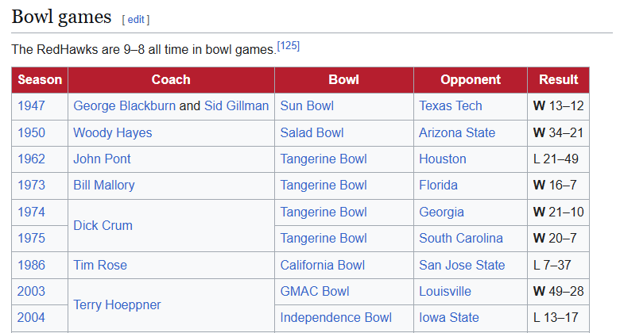

Back

Reload

Save as...

View page source

Inspect

Elements (DevTools, shortened)

<h2 id="Bowl_games">Bowl games</h2>

<p>The RedHawks are 9–8 all time in bowl games.</p>

<table class="wikitable">

<tbody>

<tr> <th>Season</th> <th>Coach</th> <th>Bowl</th> ...

<tr> <td><a href="...">1947</a></td> ...

Selector:table.wikitable15 matches9 matches

```
wiki_url = "https://en.wikipedia.org/wiki/Miami_RedHawks_football"wiki_page = httr2::request(wiki_url) |>  httr2::req_user_agent("ISA 401 class scraper (your_email@miamioh.edu)") |>  httr2::req_perform() |>  httr2::resp_body_html()wiki_tables = wiki_page |>  rvest::html_elements("table.wikitable") |>  rvest::html_table()bowl_games = wiki_tables[[4]]
```

Output appears here when a line runs.

```
{html_document}
[1] <head>\n<meta http-equiv=...
[2] <body class="skin--responsive ...
```

```
{xml_nodeset (9)}
[1] <table class="wikitable" style="text-align:center" id="mwA0 ...
[2] <table class="wikitable" id="mwA04"><tbody id="mwA08">\n<tr ...
[3] <table class="wikitable" id="mwA6c"><tbody id="mwA6g">\n<tr ...
```

A list of 9 data frames (first 5 shown)

| [[i]] | section | size |
| --- | --- | --- |
| [[1]] | Conference championships | 24 x 5 |
| [[2]] | Division championships | 9 x 5 |
| [[3]] | Head coaches | 44 x 6 |
| [[4]] | Bowl games | 17 x 5 |
| [[5]] | Cradle of Coaches | 19 x 3 |

bowl_games: 17 rows, 5 columns (4 shown)

| Season | Coach | Bowl | Opponent | Result |
| --- | --- | --- | --- | --- |
| 1947 | George Blackburn and Sid Gillman | Sun Bowl | Texas Tech | W 13–12 |
| 1950 | Woody Hayes | Salad Bowl | Arizona State | W 34–21 |
| 1962 | John Pont | Tangerine Bowl | Houston | L 21–49 |
| 1973 | Bill Mallory | Tangerine Bowl | Florida | W 16–7 |

**Goal.** Every data table on this Wikipedia page, in R. We start in the browser, not in R.

**Right-click** on the table, then choose **Inspect**.

**The Elements panel** opens at the element under the cursor. The table starts with `<table class="wikitable">`: the tag is **table**, the class is **wikitable**.

**Try the tag alone.** `table` matches **15** tables on this page. The extra 6 are the information box at the top and the navigation boxes at the bottom.

**Add the class.** `table.wikitable` means a table with class wikitable, the pattern from the CSS Selectors slides. It matches **9**: the data tables.

**Read the page in R.** The request says who is asking (next slides explain why). `resp_body_html()` parses the reply as HTML.

**Select.** `rvest::html_elements()` keeps the **9** elements that match the selector.

**Extract.** `rvest::html_table()` turns each table into a data frame. The result is a list of 9.

**Take one out.** The bowl games are the 4th data table on the page. `[[ ]]` from Class 03 takes it out of the list.

0 / 8

# The Code and the Result

```
wiki_url = "https://en.wikipedia.org/wiki/Miami_RedHawks_football" robotstxt::paths_allowed(paths = "/wiki/Miami_RedHawks_football",                         domain = "en.wikipedia.org", bot = "*") wiki_page = httr2::request(wiki_url) |>  httr2::req_user_agent("ISA 401 class scraper (your_email@miamioh.edu)") |>  httr2::req_perform() |>  httr2::resp_body_html() wiki_tables = wiki_page |>  rvest::html_elements("table.wikitable") |>  rvest::html_table() length(wiki_tables) bowl_games = wiki_tables[[4]]bowl_games
```

**Check the result against the page.** The page says the RedHawks are 9-8 in bowl games. `sum(startsWith(bowl_games$Result, "W"))` gives **9** wins in 17 games.

# Demo: Miami's ISA Course Catalog

**Question.** Build a data frame of every ISA course in Miami's 2026-2027 General Bulletin: one row per course, with its title and its description.

[figure not shown]

Page: bulletin.miamioh.edu/courses-instruction/isa/

Work through the workflow: permission, load, select, extract. Find both selectors in the browser first.

We write the code together. Type it in `class10.Rmd`.

**Step 1.** Every course title on the page, as text.

```
[1] 50
```

```
[1] "ISA 125. Introduction to Business Statistics. (3)"
[2] "ISA 177. Independent Studies. (0-6; maximum 10)"
[3] "ISA 211. Information Technology and Data Driven Decision Making in Business. (3)"
[4] "ISA 225. Principles of Business Analytics. (3)"
[5] "ISA 235. Information Technology and the Intelligent Enterprise. (3)"
```

**Step 2.** Every description. Is there one for every title?

```
[1] 50
```

```
[1] "This course provides an introduction to data, probability, sampling and its importance to analytical decision-making in business. Upon successful comp"
[2] "Introduction to the concepts of information systems and analytics used to support organizations for the non-business major. Focus is on the critical i"
```

**Step 3.** One row per course.

```
Rows: 50
Columns: 2
$ title       <chr> "ISA 125. Introduction to Business Statistics. (…
$ description <chr> "This course provides an introduction to data, p…
```

30 of the 50 descriptions mention a prerequisite.

**ISA 177 has a title but an empty description.** Why did the two vectors still line up?

**The title holds three things:** code, name, and credit hours. How would you split them into columns?

# Practice: The Fake Jobs Board

Two questions

**1.** Build a data frame with one row per job: title, company, location, date posted, and the address of its **Apply** link.

**2.** How many job titles contain the word "Python"?

Work in pairs, in `class10.Rmd`.

The page

[**realpython.github.io/fake-jobs**](https://realpython.github.io/fake-jobs/)  
A static job board that Real Python built for scraping practice. The companies and jobs are made up.

```
Rows: 100
Columns: 5
$ title      <chr> "Senior Python Developer", "Energy engineer", "Legal execut…
$ company    <chr> "Payne, Roberts and Davis", "Vasquez-Davidson", "Jackson, C…
$ location   <chr> "Stewartbury, AA", "Christopherville, AA", "Port Ericaburgh…
$ posted     <chr> "2021-04-08", "2021-04-08", "2021-04-08", "2021-04-08", "20…
$ apply_link <chr> "https://realpython.github.io/fake-jobs/jobs/senior-python-…
```

**2.** **10** titles contain "Python". The full code is in the Rmd's `fakejobs_solution` chunk.

</details>

**Each card has two links, Learn and Apply.** A selector for the links matched 200 elements for 100 jobs. How did you keep only the Apply links?

**Five selectors, five vectors of 100.** What would happen if one card had no location?

# Recap

# Summary of Main Points

By now, you should be able to do the following:

- **Determine** when scraping is permitted: `robotstxt::paths_allowed()` for the path, then the site's terms of service. hiQ v. LinkedIn is the reminder that the terms count.
- **Parse** HTML with `rvest::read_html()`, or with `httr2` and a User-Agent when a site asks who is sending the request, then select elements with a CSS selector found in the Inspector.
- **Extract** tables with `rvest::html_table()`, text with `rvest::html_text2()`, and attribute values with `rvest::html_attr()`.

**Next class (Wed, Sep 30):** Web Scraping II: many pages with `purrr::map()`, polite delays between requests, and fields that are missing on some pages.

# Before You Go

[interactive chart not shown]

# 🎯 Assignments 🎯

No new graded assignment today

Open assignments and their due dates are on the [**Canvas Assignments page**](https://miamioh.instructure.com/courses/258169/assignments). The practice questions on the right use today's three pages.

**Before you leave:** knit, then commit and push `markdowns/class10.Rmd` and `class10.html`. If it is not pushed, it is not done.

**Reading, if you want more:** [R4DS 2e, Chapter 24: Web scraping](https://r4ds.hadley.nz/webscraping) and the [rvest getting-started article](https://rvest.tidyverse.org/articles/rvest.html).

Ungraded Practice Questions

**1. Wikipedia.** Which coach took Miami to the most bowl games? Use `bowl_games`.

**2. Wikipedia.** Get the link address of every bowl in the bowl games table.

**3. Catalog.** Which ISA courses carry exactly 3 credit hours? Count them.

**4. Fake Jobs.** Which state appears most often in the locations?

**5. Your pick.** Choose a site you use, find its robots.txt and its terms, and decide whether you may scrape it.

**Answers**

1. bowl_games |> dplyr::count(Coach, sort = TRUE): Chuck Martin (7)  
2. html_elements("table.wikitable") gives 9 tables; take the 4th, then html_elements("td a") and html_attr("href"); keep the ones in the Bowl column  
3. sum(grepl("\\(3\\)$", isa_courses$title)): 36  
4. AE (37 jobs)  
5. No single answer: bring it Wednesday.